```python
pip install langchain
```

```python
pip install openai
```

```python
pip install tiktoken
```

# 5 Levels Of Summarization: Novice to Expert

Summarization is a fundamental building block of many LLM tasks. You'll frequently run into use cases where you would like to distill a large body of text into a succinct set of points.

Depending on the length of the text you'd like to summarize, you have different summarization methods to choose from.

We're going to run through 5 methods for summarization that start with Novice and end up expert. These aren't the only options, feel free to make up your own. If you find another one you like please share it with the community.

**5 Levels Of Summarization:**

1. **Summarize a couple sentences** - Basic Prompt
2. **Summarize a couple paragraphs** - Prompt Templates
3. **Summarize a couple pages** - Map Reduce
4. **Summarize an entire book** - Best Representation Vectors
5. **Summarize an unknown amount of text** - Agents

First let's import our OpenAI API Key

```python
import os



openai_api_key = "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"
```

## Summarize Long Text

If you have multiple pages you'd like to summarize, you'll likely run into a token limit.

The chain type "Map Reduce" is a method that helps with this. You first generate a summary of smaller chunks (that fit within the token limit) and then you get a summary of the summaries.

```python
from langchain import OpenAI
from langchain.chains.summarize import load_summarize_chain
from langchain.text_splitter import RecursiveCharacterTextSplitter
```

```python
paul_graham_essay = 'startupideas.txt'

with open(paul_graham_essay, 'r') as file:
    essay = file.read()
```

```python
llm.get_num_tokens(essay)
```

```
9565
```

That's too many tokens, let's split our text up into chunks so they fit into the prompt limit. Make a chunk size of 10,000 characters.

> You can think of tokens as pieces of words used for natural language processing. For English text, **1 token is approximately 4 characters** or 0.75 words. As a point of reference, the collected works of Shakespeare are about 900,000 words or 1.2M tokens.

This means the number of tokens we should expect is 10,000 / 4 = ~2,500 token chunks. But this will vary, each body of text/code will be different

```python
text_splitter = RecursiveCharacterTextSplitter(separators=["\n\n", "\n"], chunk_size=10000, chunk_overlap=500)

docs = text_splitter.create_documents([essay])
```

```python
num_docs = len(docs)

num_tokens_first_doc = llm.get_num_tokens(docs[0].page_content)

print (f"Now we have {num_docs} documents and the first one has {num_tokens_first_doc} tokens")
```

```
Now we have 5 documents and the first one has 2086 tokens
```

Great, assuming that number of tokens is consistent in the other docs we should be good to go. Let's use LangChain's [load_summarize_chain](https://python.langchain.com/en/latest/use_cases/summarization.html) to do the `map_reducing` for us. We first need to initialize our chain

```python
summary_chain = load_summarize_chain(llm=llm, chain_type='map_reduce',
#                                      verbose=True # Set verbose=True if you want to see the prompts being used
                                    )
```

Now actually run it

```python
output = summary_chain.run(docs)
```

```python
output
```

```
' Y Combinator explains that the best startup ideas come from looking for problems, preferably ones that the founders have themselves. The article discusses strategies for coming up with startup ideas on demand, such as looking in areas of expertise, talking to people about their needs, and looking …
```

We can also use custom prompts to instruct the model in chain.

Let's do an example to show the above summarization in bullet points. The map_prompt is going to stay the same (just showing it for clarity), and I'll edit the combine_prompt.

```python
map_prompt = """
Write a concise summary of the following:
"{text}"
CONCISE SUMMARY:
"""
map_prompt_template = PromptTemplate(template=map_prompt, input_variables=["text"])
```

````python
combine_prompt = """
Write a concise summary of the following text delimited by triple backquotes.
Return your response in bullet points which covers the key points of the text.
```{text}```
BULLET POINT SUMMARY:
"""
combine_prompt_template = PromptTemplate(template=combine_prompt, input_variables=["text"])
````

```python
summary_chain = load_summarize_chain(llm=llm,
                                     chain_type='map_reduce',
                                     map_prompt=map_prompt_template,
                                     combine_prompt=combine_prompt_template,
#                                      verbose=True
                                    )
```

```python
output = summary_chain.run(docs)
```

```python
print (output)
```

```
- Y Combinator suggests that the best startup ideas come from looking for problems, preferably ones that the founders have themselves.
- Good ideas should appeal to a small number of people who need it urgently.
- To find startup ideas, one should look for things that seem to be missing and be prepared to question the status quo.
- College students should use their college experience to prepare themselves for the future and build things with other students.
- Tricks for coming up with startup ideas on demand include looking in areas of expertise, talking to people about their needs, and looking for waves and gaps in the market.
- Sam Altman points out that taking the time to come up with an idea is a better strategy than most founders are willing to put in the time for.
- Paul Buchheit suggests that trying to sell something bad can lead to better ideas.
```

Chain Type:

1. **stuff**: Pass multiple documents to the LLM at the same time to process. If there are too many documents, it will exceed the token limit. Normally won't use it for summarization chain.
2. **map_reduce**: This method will summarize each document separately and then summarize summaries for each document to create the final summary.

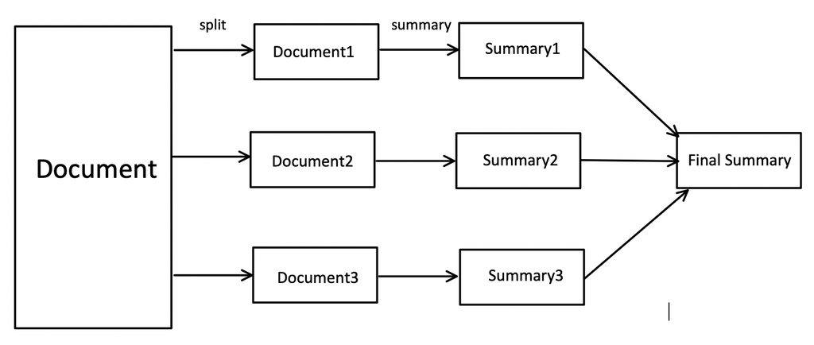

1. **refine**: This method will summarize first document first, and then use summary of the first document to summarize the second document and so on. The advantage of this method is passing previous document's summary when summarize the current document add context to the summarization task, enhance the consistancy of the summary.

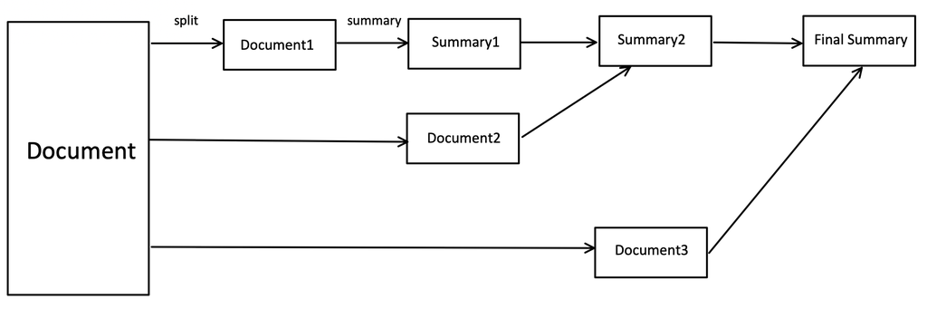

1. **map_rerank:** This method is usually used on Q&A chain not summarization chain. Given a question, it will calculate how likely a document can answer this question for every document and find the document with the highest probability. Then pad this document with question to form a prompt (question+document), send it to LLM, and LLM returns an answer.